# Lab6_10thStatsDivision

Lauren, Ryan, Katie, Chris

2/21/2018

# Overall Questions

What factors increase the probability of a delayed arrival and decrease the probability of a delayed arrival?

What tends to cause flight delays?

## Why They Are Important

Answering these questions could, potentially, allow DIA to make changes to increase the chances of a flight arriving on time. These answers could also aide individual travelers by helping them choose “better” airlines. These impacts are important because everyone who travels wants to spend more time at their destination than on the plane. Knowing the answers to our overall questions makes this desire more attainable. Besides, knowing the factors that making flights delay, the manager can do some modification with each airline and the schedules of flights. Considering the seasons, different months, and the carriers, they could make good arrangements for those flights, which saves a lot of time for passengers.

# Team Plots

```r
carr <- COflights %>% group_by(CARRIER) %>% summarise() %>% mutate(p = 1)
carr[11,1]
```

```
## # A tibble: 1 x 1
##   CARRIER
##   <chr>
## 1 WN
```

```r
for (i in 1:11) {
  delaycarr<- COflights %>% filter(ARR_DELAY >= 15 & !is.na(ARR_TIME) & CARRIER == carr[[i,1]]) %>% count(n())
  delayair <- COflights %>% filter(LATE_AIRCRAFT_DELAY >= 1& !is.na(ARR_TIME) & CARRIER == carr[[i,1]]) %>% count(n())
  carr[2][i,1] <- delayair/delaycarr
}
```

[output not shown]

```r
carr
```

```
## # A tibble: 11 x 2
##    CARRIER     p
##    <chr>   <dbl>
##  1 AA      0.456
##  2 AS      0.316
##  3 B6      0.615
##  4 DL      0.380
##  5 EV      0.438
##  6 F9      0.482
##  7 NK      0.292
##  8 OO      0.519
##  9 UA      0.406
## 10 VX      0.594
## 11 WN      0.668
```

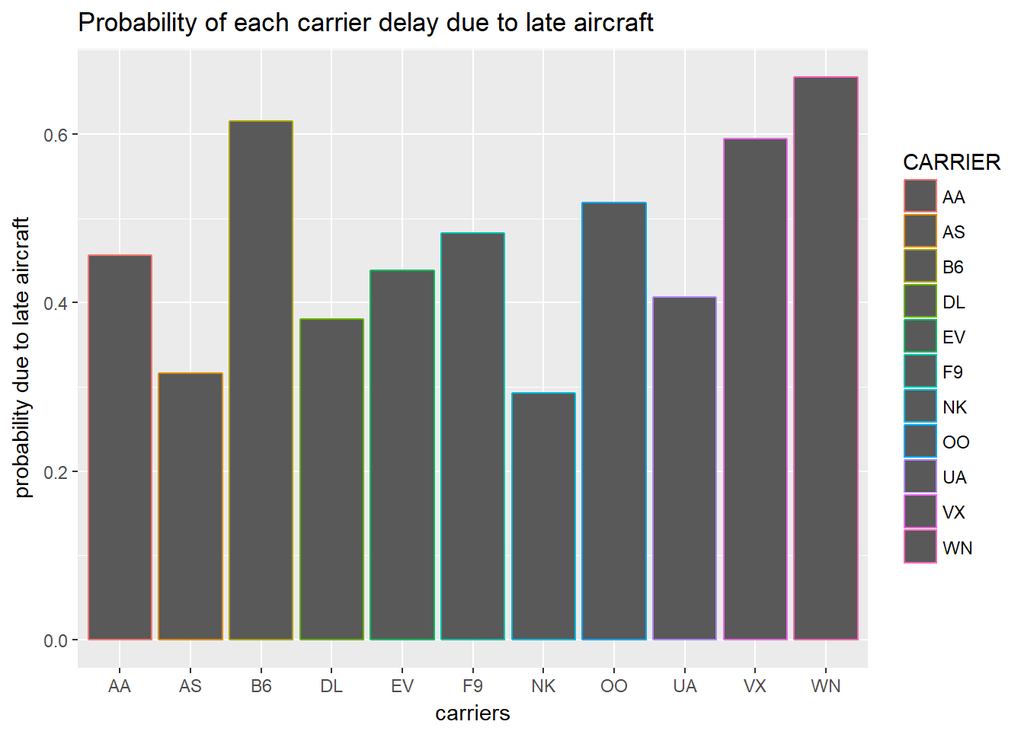

```r
ggplot(carr, mapping = aes(x = CARRIER, y = p, color = CARRIER))+
  geom_col()+
  labs(x = "carriers", y = "probability due to late aircraft",title = "Probability of each carrier delay due to late aircraft")
```

The following plot shows the covariation of the probability of a flight being delayed by more than 15 minutes with the month of the year.

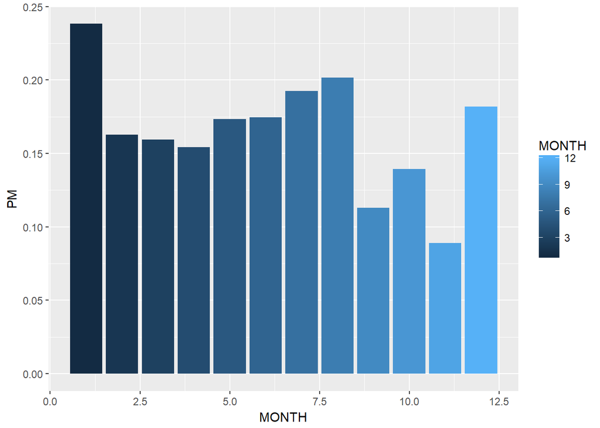

```r
monthdata <- COflights%>%group_by(MONTH)%>%summarise()

carrierdata <- COflights%>%group_by(CARRIER)%>%summarise()

pm=c()

for (i in 1:12) {
  data <- COflights%>%filter(MONTH == i)
  pm[i] <- data%>%filter(ARR_DELAY>15)%>%count()/data%>%count()
}


pc=c()

for (i in 1:11) {
  data <- COflights%>%filter(CARRIER == carrierdata$CARRIER[i])
  pc[i] <- data%>%filter(ARR_DELAY>15)%>%count()/data%>%count()
}



monthdata$PM<-as.data.frame(sapply(pm,c))

ggplot(monthdata, aes(x=MONTH,y=PM))+
  geom_col(aes(fill=MONTH))
```

This final plot shows how the probability of a flight being delayed changes based on the season.

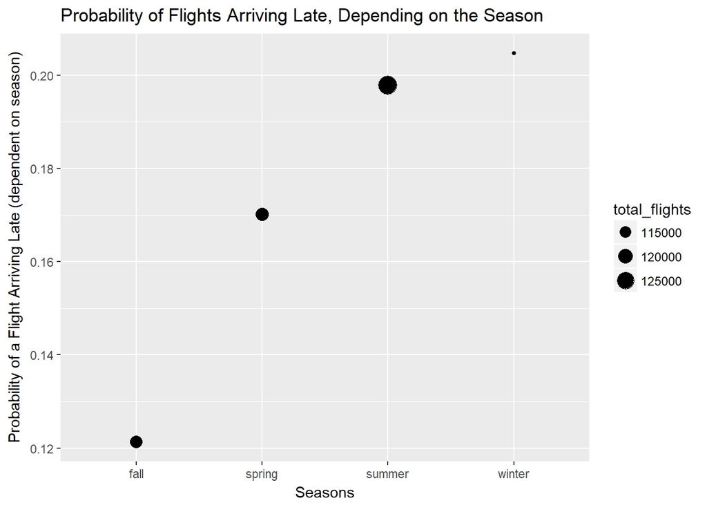

```r
spring_flights <- landed_flights %>% filter(MONTH==3 | MONTH==4 | MONTH==5)
summer_flights <- landed_flights %>% filter(MONTH==6 | MONTH==7 | MONTH==8)
fall_flights <- landed_flights %>% filter(MONTH==9 | MONTH==10 | MONTH==11)
winter_flights <- landed_flights %>% filter(MONTH==12 | MONTH==1 | MONTH==2)

spring_flights_count <- spring_flights %>% count(n())
summer_flights_count <- summer_flights %>% count(n())
fall_flights_count <- fall_flights %>% count(n())
winter_flights_count <- winter_flights %>% count(n())

spring_flights_late_count <- spring_flights %>% filter(ARR_DELAY>=15) %>% count(n())
summer_flights_late_count <- summer_flights %>% filter(ARR_DELAY>=15) %>% count(n())
fall_flights_late_count <- fall_flights %>% filter(ARR_DELAY>=15) %>% count(n())
winter_flights_late_count <- winter_flights %>% filter(ARR_DELAY>=15) %>% count(n())

spring_late_prob <- spring_flights_late_count / spring_flights_count
summer_late_prob <- summer_flights_late_count / summer_flights_count
fall_late_prob <- fall_flights_late_count / fall_flights_count
winter_late_prob <- winter_flights_late_count / winter_flights_count

seasons <- c("spring", "summer", "fall", "winter")
prob_late <- c(spring_late_prob$n, summer_late_prob$n, fall_late_prob$n, winter_late_prob$n)
total_flights <-c(spring_flights_count$n, summer_flights_count$n, fall_flights_count$n, winter_flights_count$n)
plot_data <- data_frame(seasons, prob_late, total_flights)

ggplot(plot_data, aes(x=seasons, y=prob_late, size= total_flights)) +
  geom_point() +
  ggtitle("Probability of Flights Arriving Late, Depending on the Season") +
  xlab("Seasons") +
  ylab("Probability of a Flight Arriving Late (dependent on season)" )
```

# Conlusions

Furthermore, one can see that the month of the year has a powerful effect on the probability of a flight being delayed. The effect being that during December and January, there is a high probability of a flight being delayed, while in the fall months, September, October, and November, there is a fairly low probability of the flight being delayed. This is seen even more clearly in the third plot which shows the variation of the probability of delay with the season.

Regardless, it seems clear that the carrier, the weather, and the amount of air traffic are important factors effecting the probability of a flight delay.

# Recommendation

As we could see from our individual plot and team plot, we know that to avoid the late prob. the best way that we could do is choose our flights time, the best season that we could choose is fall, the prob is relatively low that we get a arrive delay. and in winter, due to the weather or the snow situation, the late prob is higher, so maybe we could choose donot choose a flight in the snow day. another thing that we would recommad is avoide choose those company that have higher late rate like “B6”, “VX” or “WN” cause it is have higher delay rate and late aircraft in all kind of situation. in a word, our recommend is don’t choose flights durning the winter season and avoide always take a flights with carrier “B6”, “VX” or “WN”.

# Individual Findings

## Ryan

The probability of a late arrival seems to vary throughout the year, peaking in January, and with a minumum in November. What is surprising about this plot is the peak in late arrivals during the middle of the summer (July/August), and the the sudden drop off for September, October and November. The high probability of late arrivals during January is expected because of weather conditions, and holiday air traffic.

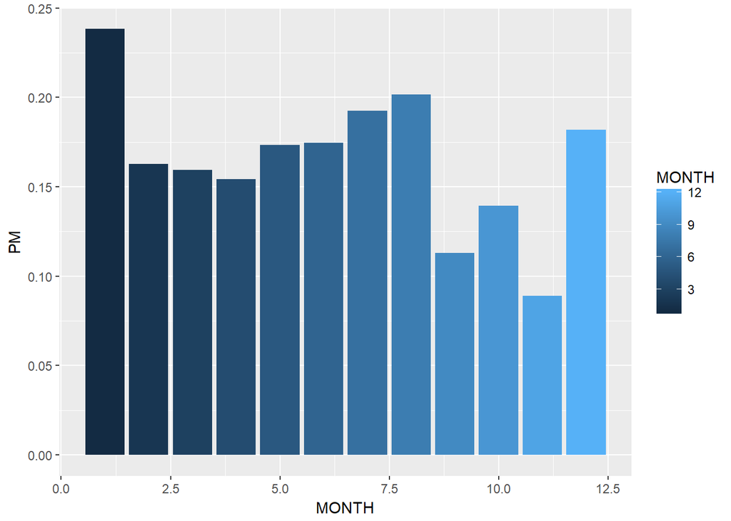

```r
monthdata <- COflights%>%group_by(MONTH)%>%summarise()

carrierdata <- COflights%>%group_by(CARRIER)%>%summarise()

pm=c()

for (i in 1:12) {
  data <- COflights%>%filter(MONTH == i)
  pm[i] <- data%>%filter(ARR_DELAY>15)%>%count()/data%>%count()
}


pc=c()

for (i in 1:11) {
  data <- COflights%>%filter(CARRIER == carrierdata$CARRIER[i])
  pc[i] <- data%>%filter(ARR_DELAY>15)%>%count()/data%>%count()
}



monthdata$PM<-as.data.frame(sapply(pm,c))

ggplot(monthdata, aes(x=MONTH,y=PM))+
  geom_col(aes(fill=MONTH))
```

From this second plot, one can easily observe that UA is the carrier which has the lowest probability of late arrival (throughout this dataset). The difference in probabilities of late arrivals between carriers is more shocking than I expected. In fact, the carrier which arrives late with the highest probability, does so almost 20% more than the carrier with the lowest probability.

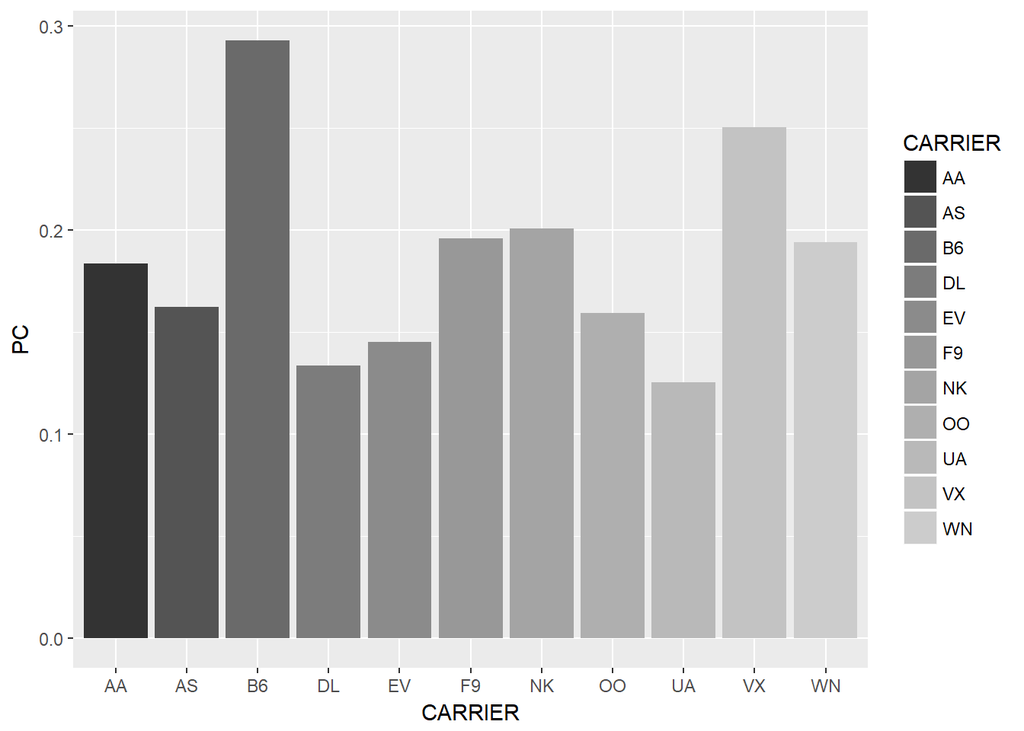

```r
carrierdata$PC<-as.data.frame(sapply(pc,c))

ggplot(carrierdata, aes(x=CARRIER,y=PC))+
  geom_col(aes(fill=CARRIER))+scale_fill_grey()
```

as for me, I was consider the carrier is the most important reason to the delay time, cause I have some personal experience, some carrier always delay and some are always on time, so I wanna compare all the carrier in American that I could get each carriers have their own late prob and show some relation between each carrier. It’s take a long time to get all the carrier in the file that we have, fianlly, I got following 11 carrier company.

first, I was try to use the count to calculate the prob directly

```r
PUA_delay<-filter(COflights,CARRIER=="UA" & ARR_DELAY>=15)%>%count()/count(COflights)
PAA_delay<-filter(COflights,CARRIER=="AA" & ARR_DELAY>=15)%>%count()/count(COflights)
PDL_delay<-filter(COflights,CARRIER=="DL" & ARR_DELAY>=15)%>%count()/count(COflights)
PB6_delay<-filter(COflights,CARRIER=="B6" & ARR_DELAY>=15)%>%count()/count(COflights)
PEV_delay<-filter(COflights,CARRIER=="EV" & ARR_DELAY>=15)%>%count()/count(COflights)
PF9_delay<-filter(COflights,CARRIER=="F9" & ARR_DELAY>=15)%>%count()/count(COflights)
PNK_delay<-filter(COflights,CARRIER=="NK" & ARR_DELAY>=15)%>%count()/count(COflights)
PVX_delay<-filter(COflights,CARRIER=="VX" & ARR_DELAY>=15)%>%count()/count(COflights)
PWN_delay<-filter(COflights,CARRIER=="WN" & ARR_DELAY>=15)%>%count()/count(COflights)
PAS_delay<-filter(COflights,CARRIER=="AS" & ARR_DELAY>=15)%>%count()/count(COflights)
POO_delay<-filter(COflights,CARRIER=="OO" & ARR_DELAY>=15)%>%count()/count(COflights)
```

it seems great, But I found that itis only divide the whole COflights by each kinds of carrier, itis not the prob of each prob and we could not get the answer, so need to consider the each carrier and calculate the prob of each carrier.

at first, I need to filter 11 new files that showns the results that the flights delay more than 15 minutes in each carrier. And if I want to calculate the prob of each carrier’s delay rate, I need to know the exact number that each carrier on time statistics. So I filter one more files that shows all carriers on time flights.

after that I just calculate each carriers late rate, it is not exact the prob but I could get the information that I need to compare each carrier.

```r
UA_delay<- filter(COflights, !is.na(ARR_TIME) & ARR_DELAY >= 15 & CARRIER=="UA" )
UA_ontime <- filter(COflights, !is.na(ARR_TIME) & CARRIER=="UA")


AA_delay<- filter(COflights, !is.na(ARR_TIME) & ARR_DELAY >= 15 & CARRIER=="AA" )
AA_ontime <- filter(COflights, !is.na(ARR_TIME),CARRIER=="AA")

DL_delay<-filter(COflights, !is.na(ARR_TIME) & ARR_DELAY >= 15 & CARRIER=="DL" )
DL_ontime <- filter(COflights, !is.na(ARR_TIME) & CARRIER=="DL")

B6_delay<-filter(COflights, !is.na(ARR_TIME) & ARR_DELAY >= 15 & CARRIER=="B6" )
B6_ontime <- filter(COflights, !is.na(ARR_TIME) & CARRIER=="B6")

EV_delay<-filter(COflights, !is.na(ARR_TIME) & ARR_DELAY >= 15 & CARRIER=="EV" )
EV_ontime <- filter(COflights, !is.na(ARR_TIME) & CARRIER=="EV")

F9_delay<-filter(COflights, !is.na(ARR_TIME) & ARR_DELAY >= 15 & CARRIER=="F9" )
F9_ontime <- filter(COflights, !is.na(ARR_TIME) & CARRIER=="F9")

NK_delay<-filter(COflights, !is.na(ARR_TIME) & ARR_DELAY >= 15 & CARRIER=="NK" )
NK_ontime <- filter(COflights, !is.na(ARR_TIME) & CARRIER=="NK")

VX_delay<-filter(COflights, !is.na(ARR_TIME) & ARR_DELAY >= 15 & CARRIER=="VX" )
VX_ontime <- filter(COflights, !is.na(ARR_TIME) & CARRIER=="VX")

WN_delay<-filter(COflights, !is.na(ARR_TIME) & ARR_DELAY >= 15 & CARRIER=="WN" )
WN_ontime <- filter(COflights, !is.na(ARR_TIME) & CARRIER=="WN")

AS_delay<-filter(COflights, !is.na(ARR_TIME) & ARR_DELAY >= 15 & CARRIER=="AS" )
AS_ontime <- filter(COflights, !is.na(ARR_TIME) & CARRIER=="AS")

OO_delay<-filter(COflights, !is.na(ARR_TIME) & ARR_DELAY >= 15 & CARRIER=="OO" )
OO_ontime <- filter(COflights, !is.na(ARR_TIME) & CARRIER=="OO")

prob_UA_LATE_RATE=  nrow(UA_delay)/nrow(UA_ontime)
prob_AA_LATE_RATE=  nrow(AA_delay)/nrow(AA_ontime)
prob_DL_LATE_RATE=  nrow(DL_delay)/nrow(DL_ontime)
prob_B6_LATE_RATE=  nrow(B6_delay)/nrow(B6_ontime)
prob_EV_LATE_RATE=  nrow(EV_delay)/nrow(EV_ontime)
prob_F9_LATE_RATE=  nrow(F9_delay)/nrow(F9_ontime)
prob_NK_LATE_RATE=  nrow(NK_delay)/nrow(NK_ontime)
prob_VX_LATE_RATE=  nrow(VX_delay)/nrow(VX_ontime)
prob_WN_LATE_RATE=  nrow(WN_delay)/nrow(WN_ontime)
prob_AS_LATE_RATE=  nrow(AS_delay)/nrow(AS_ontime)
prob_OO_LATE_RATE=  nrow(OO_delay)/nrow(OO_ontime)
```

than I need use the plot function to show each carrier prob. at first, I used a dataframe to get the new data files and do the x,y lab.

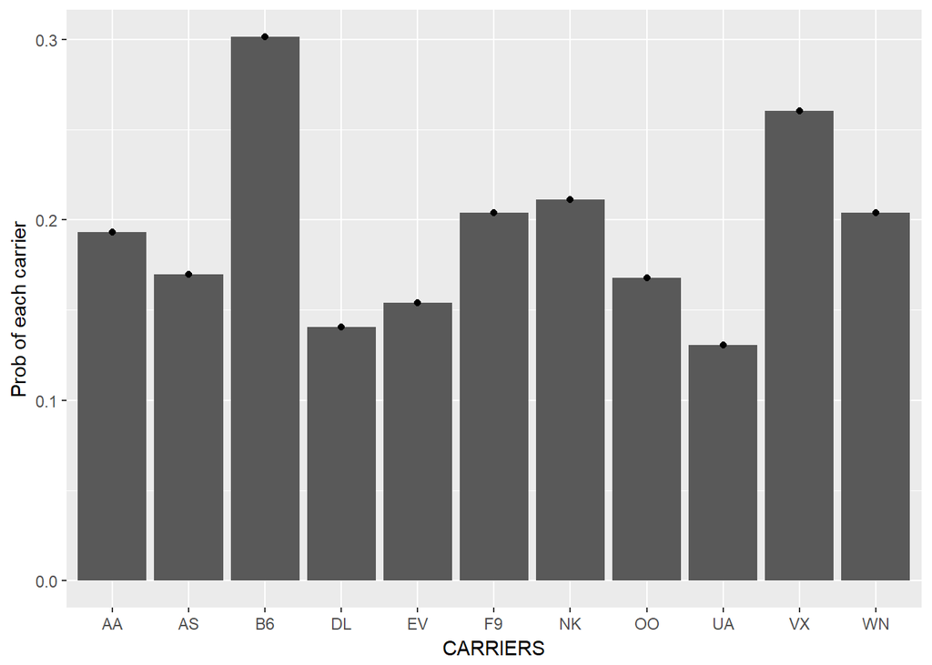

```r
wholeprob<- data.frame(x=c("UA","AA","DL","B6","EV","F9","NK","VX","WN","AS","OO"),y=c(prob_UA_LATE_RATE,prob_AA_LATE_RATE,prob_DL_LATE_RATE,prob_B6_LATE_RATE,prob_EV_LATE_RATE,prob_F9_LATE_RATE,prob_NK_LATE_RATE,prob_VX_LATE_RATE,prob_WN_LATE_RATE,prob_AS_LATE_RATE,prob_OO_LATE_RATE))

ggplot(data = wholeprob, aes(x,y)) + geom_col()+geom_point()+ xlab("CARRIERS")+ylab("Prob of each carrier")
```

after we got this graph, I could easily know the stituation that each carriers prob. like that the carrier “B6” and “VX” have the most late rate, the carrier “DL”, “UA” and “EV” have relatively low late rate, and the rest of six carrier have median late rate.

So I could get the answer to my question, for me or for everyone, when they have a plan to travel or go to another place by plane, the best carrier that he could choose is “DL”, “UA” and “EV”. Itis the most on-time carrier when we consider the aircraft in DEN. for my personal, next time I take a vacation I must choose those flights that have relatively low late rate carrier.

## Katie

For my personal experience, I think the weather and the late aircraft may be the big reasons that affect the delay of flights. So I first look at each month, and calculate the probability of delayed flights due to the weather in each month and use ggplot to show the tendency of the probability based on weather and month. Then I classify each carrier, and look at their probability of late aircraft, then plot bar graph to show which one has the greatest probability because of the late aircraft.

```r
delay <- tibble(month = 1:12, p1 = 1:12)
delay[2][3,1]
```

```
## # A tibble: 1 x 1
##      p1
##   <int>
## 1     3
```

```r
for (j in 1:12) {
  delaymonth <- COflights %>% filter(ARR_DELAY >= 15 & !is.na(ARR_TIME) & MONTH == j) %>% count(n())
  delayweather <- COflights %>% filter(WEATHER_DELAY >= 1&!is.na(ARR_TIME) & MONTH == j) %>% count(n())
  delay[2][j,1] <- delayweather/delaymonth
    }
```

[output not shown]

```r
delay
```

```
## # A tibble: 12 x 2
##    month     p1
##    <int>  <dbl>
##  1     1 0.0597
##  2     2 0.0556
##  3     3 0.0412
##  4     4 0.0419
##  5     5 0.0394
##  6     6 0.0412
##  7     7 0.0520
##  8     8 0.0539
##  9     9 0.0180
## 10    10 0.0256
## 11    11 0.0243
## 12    12 0.0601
```

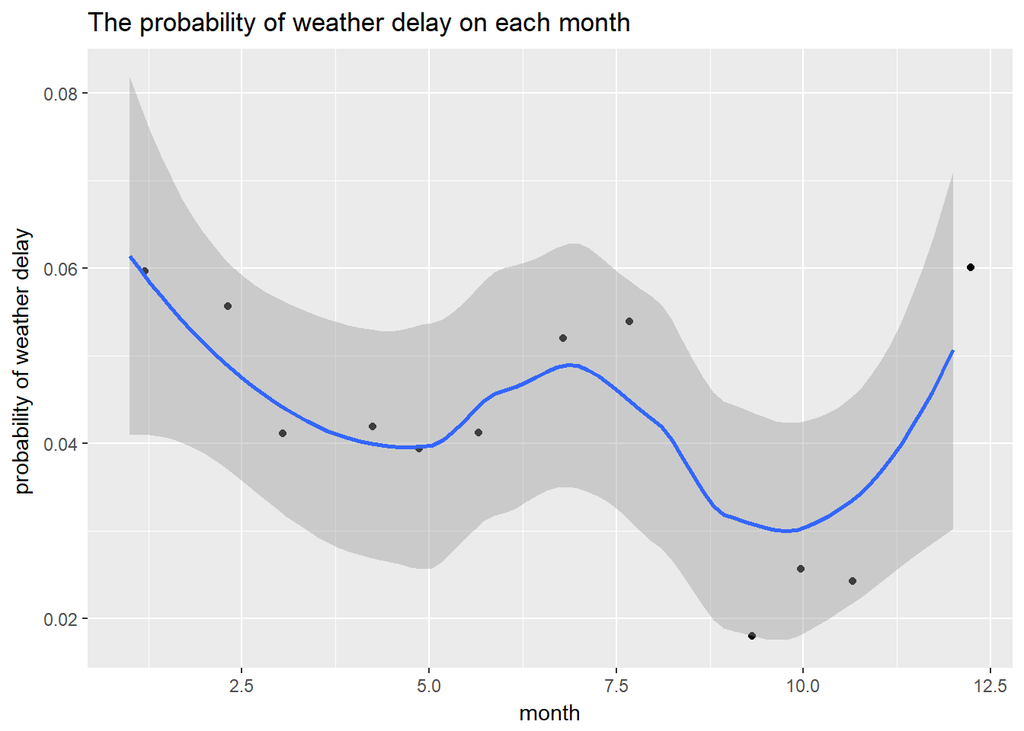

```r
ggplot(delay, mapping = aes(x = month, y = p1))+
  geom_jitter()+
  geom_smooth(method = "loess")+
  labs(x = "month", y = "probability of weather delay ", title = "The probability of weather delay on each month")
```

```r
carr <- COflights %>% group_by(CARRIER) %>% summarise() %>% mutate(p = 1)
carr[11,1]
```

```
## # A tibble: 1 x 1
##   CARRIER
##   <chr>
## 1 WN
```

```r
for (i in 1:11) {
  delaycarr<- COflights %>% filter(ARR_DELAY >= 15 & !is.na(ARR_TIME) & CARRIER == carr[[i,1]]) %>% count(n())
  delayair <- COflights %>% filter(LATE_AIRCRAFT_DELAY >= 1& !is.na(ARR_TIME) & CARRIER == carr[[i,1]]) %>% count(n())
  carr[2][i,1] <- delayair/delaycarr
}
```

[output not shown]

```r
carr
```

```
## # A tibble: 11 x 2
##    CARRIER     p
##    <chr>   <dbl>
##  1 AA      0.456
##  2 AS      0.316
##  3 B6      0.615
##  4 DL      0.380
##  5 EV      0.438
##  6 F9      0.482
##  7 NK      0.292
##  8 OO      0.519
##  9 UA      0.406
## 10 VX      0.594
## 11 WN      0.668
```

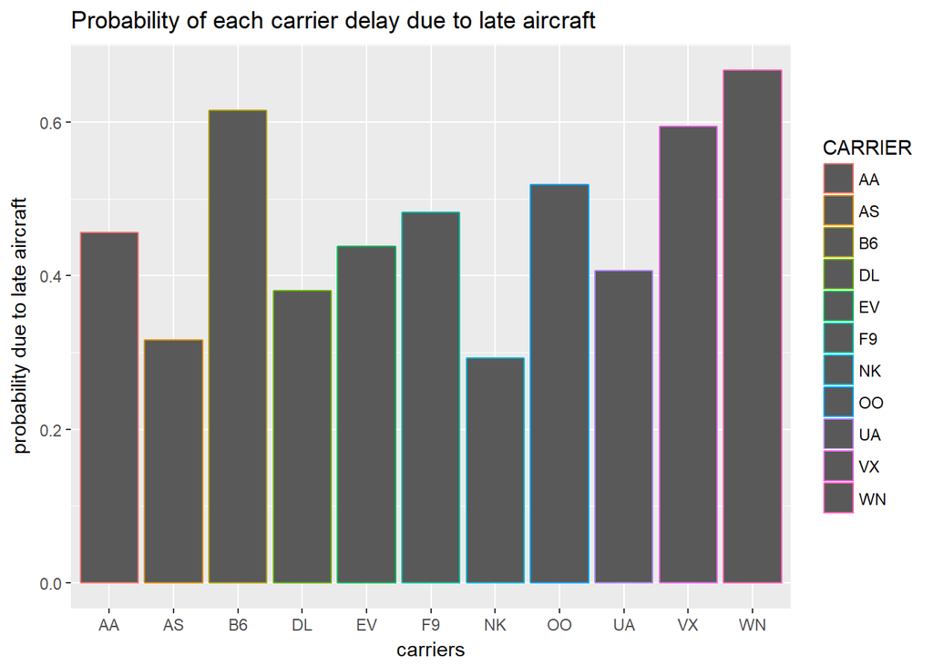

```r
ggplot(carr, mapping = aes(x = CARRIER, y = p, color = CARRIER))+
  geom_col()+
  labs(x = "carriers", y = "probability due to late aircraft",title = "Probability of each carrier delay due to late aircraft")
```

The bar chart above shows for each carrier, the probability that their flights delay because of the late aircraft. I use the goem_bar in ggplot to show the range of their probabilities. The bar chart is more easy to read and pretty straightforward to illustrate the highest and the lowest probability for each carrier. Thus from the plot, we can visualize the highest one is WN, and the lowest is NK, which is obvious from the plot. So maybe the manager can allow more NK carriers in Colorado, in order to lower the chances of flight delay.

## Lauren

I considered how the seasons impact the tardiness of flights and if weather is a confounding variable. Please take note that I determined the seasons as such; Spring: March, April, May; Summer: June, July, August; Fall: Spetember, October, November; and Winter: December, January, February.

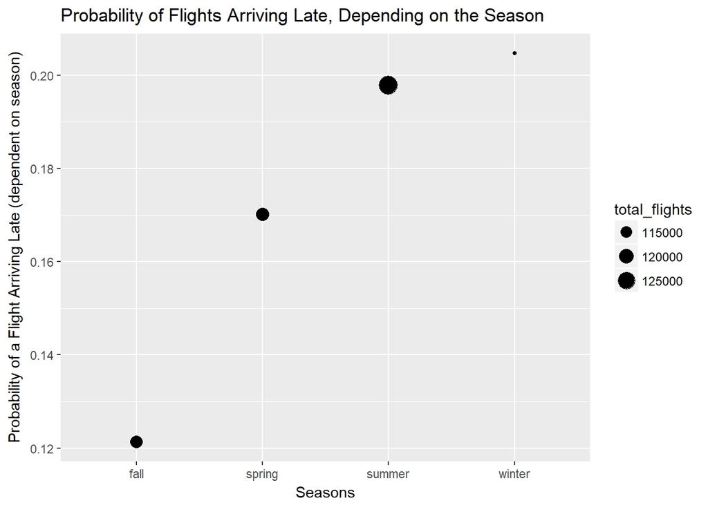

```r
spring_flights <- landed_flights %>% filter(MONTH==3 | MONTH==4 | MONTH==5)
summer_flights <- landed_flights %>% filter(MONTH==6 | MONTH==7 | MONTH==8)
fall_flights <- landed_flights %>% filter(MONTH==9 | MONTH==10 | MONTH==11)
winter_flights <- landed_flights %>% filter(MONTH==12 | MONTH==1 | MONTH==2)

spring_flights_count <- spring_flights %>% count(n())
summer_flights_count <- summer_flights %>% count(n())
fall_flights_count <- fall_flights %>% count(n())
winter_flights_count <- winter_flights %>% count(n())

spring_flights_late_count <- spring_flights %>% filter(ARR_DELAY>=15) %>% count(n())
summer_flights_late_count <- summer_flights %>% filter(ARR_DELAY>=15) %>% count(n())
fall_flights_late_count <- fall_flights %>% filter(ARR_DELAY>=15) %>% count(n())
winter_flights_late_count <- winter_flights %>% filter(ARR_DELAY>=15) %>% count(n())

spring_late_prob <- spring_flights_late_count / spring_flights_count
summer_late_prob <- summer_flights_late_count / summer_flights_count
fall_late_prob <- fall_flights_late_count / fall_flights_count
winter_late_prob <- winter_flights_late_count / winter_flights_count

seasons <- c("spring", "summer", "fall", "winter")
prob_late <- c(spring_late_prob$n, summer_late_prob$n, fall_late_prob$n, winter_late_prob$n)
total_flights <-c(spring_flights_count$n, summer_flights_count$n, fall_flights_count$n, winter_flights_count$n)
plot_data <- data_frame(seasons, prob_late, total_flights)

ggplot(plot_data, aes(x=seasons, y=prob_late, size= total_flights)) +
  geom_point() +
  ggtitle("Probability of Flights Arriving Late, Depending on the Season") +
  xlab("Seasons") +
  ylab("Probability of a Flight Arriving Late (dependent on season)" )
```

As we can see from the above plot, a larger probability of winter flights tend to arrive more than 15 minutes late compared to the other seasons. Additionally, the winter season has about 110,000 completed flights, which is the smallest number among the seasons. This is reasonable because we are considering flights that departed from or landed in an airport in Colorado and snow is obviously impactful during the winter months. However, Colorado sees a fair share of snow in the spring months (March, April, May) as well. Perhaps I could adjust for this by only focusing on flights departing from DIA.

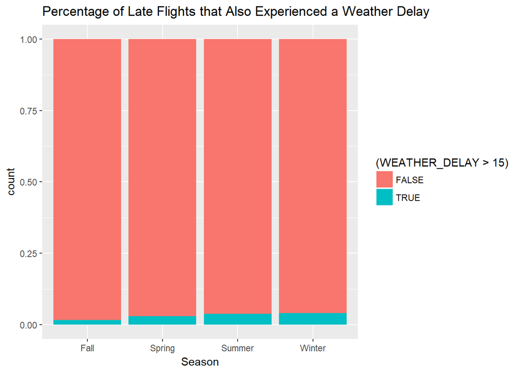

```r
landed_flights_seasons <- landed_flights %>% mutate(season =
                                              case_when((MONTH==3|MONTH==4|MONTH==5)~"Spring",
                                                    (MONTH==6 | MONTH==7 | MONTH==8)~"Summer",
                                                    (MONTH==9 | MONTH==10 | MONTH==11)~"Fall",
                                                    (MONTH==12 | MONTH==1|MONTH==2)~"Winter"))


seasons_late_flights <- landed_flights_seasons %>% filter(ARR_DELAY>15)

ggplot(seasons_late_flights, aes(x=factor(season), fill=(WEATHER_DELAY>15))) +
  geom_bar(position="fill") +
  ggtitle("Percentage of Late Flights that Also Experienced a Weather Delay") +
  xlab("Season")
```

This plot shows us that the winter months (December, January, February) tend to have a higher percentage of weather delays amongst their late flights.

```r
late_spring_flights_weather_count <- spring_flights %>%
  filter(ARR_DELAY>15 &WEATHER_DELAY>15) %>% count(n())
prob_spring_weather <- late_spring_flights_weather_count / spring_flights_late_count

late_summer_flights_weather_count <- summer_flights %>%
  filter(ARR_DELAY>15 &WEATHER_DELAY>15) %>% count(n())
prob_summer_weather <- late_summer_flights_weather_count / summer_flights_late_count

late_fall_flights_weather_count <- fall_flights %>%
  filter(ARR_DELAY>15 &WEATHER_DELAY>15) %>% count(n())
prob_fall_weather <- late_fall_flights_weather_count / fall_flights_late_count

late_winter_flights_weather_count <- winter_flights %>%
  filter(ARR_DELAY>15 &WEATHER_DELAY>15) %>% count(n())
prob_winter_weather <- late_winter_flights_weather_count / winter_flights_late_count
```

```r
prob_spring_weather$n
```

```
## [1] 0.02820153
```

```r
prob_summer_weather$n
```

```
## [1] 0.03666706
```

```r
prob_fall_weather$n
```

```
## [1] 0.0161599
```

```r
prob_winter_weather$n
```

```
## [1] 0.0390397
```

The probability of a flight having experienced a weather delay given that it arrived late is 3.9% in the winter season, 3.6% during the summer season, 2.8% during the spring season, and 1.6% during the fall season.

Ultimately, if a passenger wants to be have a higher chance of arriving on time, he or she sould travel in the fall. This obviously is not always reasonable, so those traveling in the winter have a higher chance of arriving more than 15 minutes late and nearly 4% of those delays will be compounded with weather delays.

These findings are important for indiviudal travelers as well as the Denver airport. With this knowledge, travelers can decide to allow for longer layovers in the winter in order to avoid missing a connection. They can also recognize that their chances of being delayed are higher so they should stay relaxed if it happens. The airport can use this knowledge to know which seasons they need to have more staff on hand. Delayed flights tend to cause angry passengers. For example, the summer months seem to have the largest number of flights and a fair percentage of those flights are delayed; I would recommend that the airport have a larger staff force during these months to handle the large amounts of disgruntled customers.

# Lauren

Lauren outlined the project as a whole to help us get started. She then discussed why the team’s general questions are important. Lauren implemented the size aesthetic in her first plot in order to visualize how many completed flights occur in each season abd she used the label non-default layers.

# Katie

Katie added some parts of the importance of delay factors, and compared the weather delay on each month in her first plot. She found the tendency of the probability on each month due to the flight delay, which could help manager to schedule flight time on each month to aviod delay. Then for every airline, she found their delay probabilities due to the late aircraft. The bar chart above is obvious to see the delay for each carrier.

# Chris

Chris added his own interesting problem that he found, the carrier that would influence our late rate and give us his own opinions about the plan that when we want to choose a carrier to go travel, also, he do the recommand part and submit our lab.

# Ryan

Aside from his individual section, Ryan selected the relevant plots to be shown in the team plots section. He also wrote the conclusions section.